# Applied Multivariate Statistical Analysis

Exercise 1

Kasper Veje Jakobsen (kasja20@student.sdu.dk)

2025-04-07

## Installing the st514 Package

The first step is to install the required package for the course. This package contains datasets from the textbook and useful functions.

```r
# Install the st514 package from the provided URL
# install.packages("https://imada.sdu.dk/u/chdj/ST514/F20/st514_1.0.tar.gz",
#                  repos = NULL, type = "source")

# Load the package
library(st514)
```

Note: You only need to install the package once, but you will need to load it with `library(st514)` in each new R session.

# Exercise 1: Working with Matrices in R

## 1.1 Create the 4×3 matrix

```r
# Create the specified 4×3 matrix
X <- matrix(c(1, 2, 3, 4, 2, 4, 5, 7, 3, 6, 7, 8), nrow = 4, ncol = 3, byrow = FALSE)

# Display the matrix
X
```

```
##      [,1] [,2] [,3]
## [1,]    1    2    3
## [2,]    2    4    6
## [3,]    3    5    7
## [4,]    4    7    8
```

## 1.2 Compute the transpose

```r
# Compute the transpose of X
X_t <- t(X)

# Display the transpose
X_t
```

```
##      [,1] [,2] [,3] [,4]
## [1,]    1    2    3    4
## [2,]    2    4    5    7
## [3,]    3    6    7    8
```

## 1.3 Compute the matrix product

```r
# Compute X × X_t (matrix multiplication)
X_prod <- X %*% X_t

# Display the resulting matrix
X_prod
```

```
##      [,1] [,2] [,3] [,4]
## [1,]   14   28   34   42
## [2,]   28   56   68   84
## [3,]   34   68   83  103
## [4,]   42   84  103  129
```

## 1.4 Create an invertible matrix and compute its inverse

```r
# Create the invertible matrix Y
Y <- matrix(c(2, 1, 1, 2), nrow = 2, ncol = 2, byrow = TRUE)

# Display Y
Y
```

```
##      [,1] [,2]
## [1,]    2    1
## [2,]    1    2
```

```r
# Compute the inverse of Y
Y_inv <- solve(Y)

# Display the inverse
Y_inv
```

```
##            [,1]       [,2]
## [1,]  0.6666667 -0.3333333
## [2,] -0.3333333  0.6666667
```

```r
# Verify that Y × Y_inv = I (identity matrix)
Y %*% Y_inv
```

```
##      [,1] [,2]
## [1,]    1    0
## [2,]    0    1
```

# Exercise 2: Column-Wise Operations

## 2.1 Compute column means

```r
# Compute the mean of each column of X
col_means <- colMeans(X)

# Display the column means
col_means
```

```
## [1] 2.5 4.5 6.0
```

## 2.2 Standardize the matrix

```r
X
```

```
##      [,1] [,2] [,3]
## [1,]    1    2    3
## [2,]    2    4    6
## [3,]    3    5    7
## [4,]    4    7    8
```

```r
# Standardize X (subtract mean and divide by standard deviation for each column)
X_scaled <- scale(X)

# Display the standardized matrix
X_scaled
```

```
##            [,1]       [,2]       [,3]
## [1,] -1.1618950 -1.2009612 -1.3887301
## [2,] -0.3872983 -0.2401922  0.0000000
## [3,]  0.3872983  0.2401922  0.4629100
## [4,]  1.1618950  1.2009612  0.9258201
## attr(,"scaled:center")
## [1] 2.5 4.5 6.0
## attr(,"scaled:scale")
## [1] 1.290994 2.081666 2.160247
```

```r
# What does scale actually do?

# Compute column means and column sd
X_mean <- colMeans(X)
x_std <- c(sd(X[, 1]), sd(X[, 2]), sd(X[, 3]))

# Initialize a matrix to store the standardized values
X_scaled_manual <- matrix(NA, nrow = 4, ncol = 3)

# Fill in the standardized values manually
X_scaled_manual[, 1] <- (X[, 1] - X_mean[1]) / x_std[1]
X_scaled_manual[, 2] <- (X[, 2] - X_mean[2]) / x_std[2]
X_scaled_manual[, 3] <- (X[, 3] - X_mean[3]) / x_std[3]

# Show result
X_scaled_manual
```

```
##            [,1]       [,2]       [,3]
## [1,] -1.1618950 -1.2009612 -1.3887301
## [2,] -0.3872983 -0.2401922  0.0000000
## [3,]  0.3872983  0.2401922  0.4629100
## [4,]  1.1618950  1.2009612  0.9258201
```

## 2.3 Verify standardization

```r
# Verify that column means are approximately 0
colMeans(X_scaled)
```

```
## [1] 0 0 0
```

```r
# Verify that column standard deviations are approximately 1
# Using apply to calculate the standard deviation of each column
apply(X_scaled, 2, sd)
```

```
## [1] 1 1 1
```

# Exercise 3: Covariance and Correlation

## 3.1 Compute the covariance matrix

```r
# Compute the covariance matrix of X
cov_matrix <- cov(X)

# Display the covariance matrix
cov_matrix
```

```
##          [,1]     [,2]     [,3]
## [1,] 1.666667 2.666667 2.666667
## [2,] 2.666667 4.333333 4.333333
## [3,] 2.666667 4.333333 4.666667
```

## 3.2 Compute the correlation matrix

```r
# Compute the correlation matrix of X
cor_matrix <- cor(X)

# Display the correlation matrix
cor_matrix
```

```
##           [,1]      [,2]      [,3]
## [1,] 1.0000000 0.9922779 0.9561829
## [2,] 0.9922779 1.0000000 0.9636241
## [3,] 0.9561829 0.9636241 1.0000000
```

## 3.3 Difference between covariance and correlation

The difference between covariance and correlation:

1. **Covariance** measures how two variables change together, but its value depends on the scale of the variables.
2. **Correlation** normalizes the covariance by dividing by the product of the standard deviations, resulting in a value between -1 and 1.

Based on the computed matrices: - The covariance matrix elements can be any real number and depend on the scales of the variables. - The correlation matrix elements are always between -1 and 1, with the diagonal elements being exactly 1.

The correlation values differ from the covariance values because they are standardized. This standardization allows for comparing the strength of relationships between different pairs of variables regardless of their scales.

# Exercise 4: Eigenvalues and Eigenvectors

## 4.1 Compute eigenvalues and eigenvectors

```r
# Compute the eigenvalues and eigenvectors of the covariance matrix of X
eig <- eigen(cov_matrix)

# Display the eigenvalues
eig$values
```

```
## [1] 10.45444307  0.19395829  0.01826531
```

```r
# Display the eigenvectors
eig$vectors
```

```
##            [,1]       [,2]        [,3]
## [1,] -0.3943214 -0.3823657  0.83564775
## [2,] -0.6392006 -0.5392033 -0.54834506
## [3,] -0.6602524  0.7503708  0.03178898
```

## 4.2 Verify the decomposition

```r
# Create a diagonal matrix D of eigenvalues
D <- diag(eig$values)

# Extract eigenvector matrix V
V <- eig$vectors

# Verify the decomposition: V %*% D %*% solve(V) should equal cov_matrix
decomp_verification <- V %*% D %*% solve(V)

# Display the result of the verification
decomp_verification
```

```
##          [,1]     [,2]     [,3]
## [1,] 1.666667 2.666667 2.666667
## [2,] 2.666667 4.333333 4.333333
## [3,] 2.666667 4.333333 4.666667
```

```r
# Check if the original covariance matrix and the decomposition result are approximately equal
all.equal(cov_matrix, decomp_verification)
```

```
## [1] TRUE
```

# Exercise 5: Visualizing Relationships Between Variables

## 5.1 Generate random data

```r
# Set seed for reproducibility
set.seed(123)

# Generate a 50×3 matrix with standard normal values
data <- matrix(rnorm(50*3), nrow = 50, ncol = 3)

# Assign column names
colnames(data) <- c("X1", "X2", "X3")

# Display the first few rows of the data
head(data)
```

```
##               X1          X2          X3
## [1,] -0.56047565  0.25331851 -0.71040656
## [2,] -0.23017749 -0.02854676  0.25688371
## [3,]  1.55870831 -0.04287046 -0.24669188
## [4,]  0.07050839  1.36860228 -0.34754260
## [5,]  0.12928774 -0.22577099 -0.95161857
## [6,]  1.71506499  1.51647060 -0.04502772
```

## 5.2 Create a scatterplot matrix

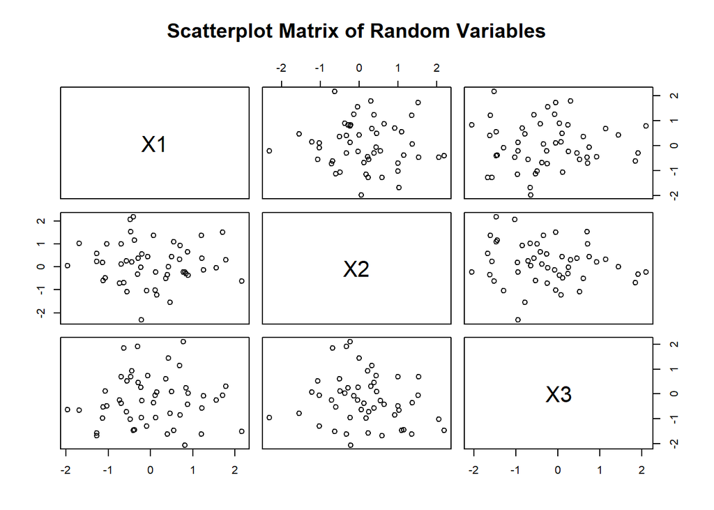

```r
# Create a scatterplot matrix
pairs(data, main = "Scatterplot Matrix of Random Variables")
```

## 5.3 Relationship assessment

Based on the scatterplot matrix:

The scatterplots show no clear pattern or strong relationship between any pair of variables. This is expected because we generated the data from a standard normal distribution with independent variables. The points appear randomly scattered, which indicates little to no linear relationship between the variables.

If we were to compute the correlation matrix for this data, we would expect values close to 0:

```r
# Compute and display the correlation matrix for the randomly generated data
cor(data)
```

```
##             X1          X2          X3
## X1  1.00000000 -0.03586983  0.02910612
## X2 -0.03586983  1.00000000 -0.15607113
## X3  0.02910612 -0.15607113  1.00000000
```

As expected, the off-diagonal elements are close to 0, confirming the lack of strong relationships between the variables.